# Summary of JAGS model

## Run Summary

Chains : 50  
Burn-in : 500100  
Samples per chain : 100  
Total samples : 5000  
Thinning : 7000  
Duration: 1.9 days  
Start Time: 2026-06-20 06:26  
End Time: 2026-06-22 04:49

## Posterior Summary

|  | Lower95 | Median | Upper95 | Mean | SD | Mode | MCerr | MC%ofSD | SSeff | AC.70000 | psrf |
| --- | --- | --- | --- | --- | --- | --- | --- | --- | --- | --- | --- |
| **deviance** | 44511 | 44565 | 44617 | 44565 | 27.05 | 44565 | 0.3582 | 1.3 | 5701 | -0.01834 | 1 |
| **sire.vcov[1,1]** | 0.0009319 | 3.118 | 8.347 | 3.618 | 2.537 | 2.26 | 0.03387 | 1.3 | 5610 | -0.02376 | 1.001 |
| **sire.vcov[2,1]** | -5.889 | 0.7016 | 8.574 | 0.9738 | 3.658 | 0.2798 | 0.0518 | 1.4 | 4988 | 0.0163 | 1.002 |
| **sire.vcov[3,1]** | -0.2728 | 0.3983 | 1.338 | 0.4669 | 0.4304 | 0.3201 | 0.00602 | 1.4 | 5113 | -0.0006414 | 1.004 |
| **sire.vcov[4,1]** | -0.9144 | -0.05742 | 0.7773 | -0.06137 | 0.418 | -0.05141 | 0.005872 | 1.4 | 5068 | -0.01899 | 1.005 |
| **sire.vcov[1,2]** | -5.889 | 0.7016 | 8.574 | 0.9738 | 3.658 | 0.2798 | 0.0518 | 1.4 | 4988 | 0.0163 | 1.002 |
| **sire.vcov[2,2]** | 0.9875 | 26.3 | 62.56 | 29.59 | 17.59 | 22.61 | 0.2256 | 1.3 | 6080 | -0.0118 | 0.9991 |
| **sire.vcov[3,2]** | -1.772 | 0.2016 | 2.207 | 0.2556 | 0.9831 | 0.2057 | 0.01432 | 1.5 | 4713 | 0.001736 | 1.001 |
| **sire.vcov[4,2]** | -1.597 | 0.32 | 2.644 | 0.3842 | 1.049 | 0.316 | 0.01434 | 1.4 | 5354 | -0.006434 | 1.003 |
| **sire.vcov[1,3]** | -0.2728 | 0.3983 | 1.338 | 0.4669 | 0.4304 | 0.3201 | 0.00602 | 1.4 | 5113 | -0.0006414 | 1.004 |
| **sire.vcov[2,3]** | -1.772 | 0.2016 | 2.207 | 0.2556 | 0.9831 | 0.2057 | 0.01432 | 1.5 | 4713 | 0.001736 | 1.001 |
| **sire.vcov[3,3]** | 0.0006894 | 0.2258 | 0.6429 | 0.2679 | 0.1975 | 0.1685 | 0.002819 | 1.4 | 4906 | -0.01022 | 1.001 |
| **sire.vcov[4,3]** | -0.1972 | 0.01453 | 0.2464 | 0.02274 | 0.1099 | 0.004108 | 0.001677 | 1.5 | 4292 | -0.01521 | 1.009 |
| **sire.vcov[1,4]** | -0.9144 | -0.05742 | 0.7773 | -0.06137 | 0.418 | -0.05141 | 0.005872 | 1.4 | 5068 | -0.01899 | 1.005 |
| **sire.vcov[2,4]** | -1.597 | 0.32 | 2.644 | 0.3842 | 1.049 | 0.316 | 0.01434 | 1.4 | 5354 | -0.006434 | 1.003 |
| **sire.vcov[3,4]** | -0.1972 | 0.01453 | 0.2464 | 0.02274 | 0.1099 | 0.004108 | 0.001677 | 1.5 | 4292 | -0.01521 | 1.009 |
| **sire.vcov[4,4]** | 0.00025 | 0.238 | 0.6979 | 0.2889 | 0.2184 | 0.1663 | 0.003033 | 1.4 | 5185 | -0.002022 | 1.001 |
| **dam.vcov[1,1]** | 10.7 | 25.24 | 46.97 | 27.16 | 10.28 | 23.21 | 0.1284 | 1.2 | 6406 | -0.006921 | 1.002 |
| **dam.vcov[2,1]** | -4.725 | 24.14 | 65.01 | 26.19 | 18.21 | 21.79 | 0.2446 | 1.3 | 5543 | -0.01713 | 0.9992 |
| **dam.vcov[3,1]** | -0.4255 | 1.446 | 3.976 | 1.576 | 1.132 | 1.32 | 0.01562 | 1.4 | 5253 | -0.006726 | 1 |
| **dam.vcov[4,1]** | -1.363 | 0.4874 | 2.656 | 0.5472 | 1.016 | 0.434 | 0.01354 | 1.3 | 5626 | -0.01462 | 1.001 |
| **dam.vcov[1,2]** | -4.725 | 24.14 | 65.01 | 26.19 | 18.21 | 21.79 | 0.2446 | 1.3 | 5543 | -0.01713 | 0.9992 |
| **dam.vcov[2,2]** | 82.53 | 176.5 | 320.3 | 188.9 | 67.76 | 157.3 | 0.943 | 1.4 | 5162 | 0.001775 | 1 |
| **dam.vcov[3,2]** | -1.604 | 4.019 | 9.871 | 4.258 | 2.903 | 3.755 | 0.03817 | 1.3 | 5786 | -0.01913 | 1.001 |
| **dam.vcov[4,2]** | -7.104 | -2.145 | 2.36 | -2.298 | 2.395 | -1.994 | 0.03278 | 1.4 | 5337 | 0.01223 | 1 |
| **dam.vcov[1,3]** | -0.4255 | 1.446 | 3.976 | 1.576 | 1.132 | 1.32 | 0.01562 | 1.4 | 5253 | -0.006726 | 1 |
| **dam.vcov[2,3]** | -1.604 | 4.019 | 9.871 | 4.258 | 2.903 | 3.755 | 0.03817 | 1.3 | 5786 | -0.01913 | 1.001 |
| **dam.vcov[3,3]** | 0.09544 | 0.5018 | 1.137 | 0.56 | 0.3016 | 0.4308 | 0.004105 | 1.4 | 5398 | -0.01904 | 1.003 |
| **dam.vcov[4,3]** | -0.5161 | -0.1614 | 0.09842 | -0.1774 | 0.1599 | -0.1442 | 0.002233 | 1.4 | 5127 | -0.01208 | 1.004 |
| **dam.vcov[1,4]** | -1.363 | 0.4874 | 2.656 | 0.5472 | 1.016 | 0.434 | 0.01354 | 1.3 | 5626 | -0.01462 | 1.001 |

[output cut: 97 more lines]

## V<sub>A</sub>

Latent scale

| metric | lower.hdi | median | mode | upper.hdi | pr.lt.hdi | pr.gt.hdi | 5pc.exceeds | pct.gt.0 |
| --- | --- | --- | --- | --- | --- | --- | --- | --- |
| Var(Trunk) | 0.003728 | 12.47 | 9.008 | 33.39 | 0 | 0.0498 | 33.38 | 1 |
| Var(Tail) | 3.95 | 105.2 | 91.14 | 250.2 | 0.0038 | 0.046 | 247.7 | 1 |
| Var(Hatch) | 0.002758 | 0.9032 | 0.675 | 2.572 | 0 | 0.0498 | 2.568 | 1 |
| Var(Settle\|Hatch) | 0.001 | 0.9521 | 0.6603 | 2.792 | 0.0002 | 0.0496 | 2.787 | 1 |
| Cov(Trunk, Tail) | -23.56 | 2.806 | 1.152 | 34.3 | 0.0224 | 0.0274 | 29.05 | 0.6008 |
| Cov(Trunk, Hatch) | -1.091 | 1.593 | 1.309 | 5.351 | 0.0104 | 0.0394 | 5.085 | 0.9036 |
| Cov(Trunk, Settle\|Hatch) | -3.658 | -0.2297 | -0.197 | 3.109 | 0.0274 | 0.0224 | 2.401 | 0.4276 |
| Cov(Tail, Hatch) | -7.087 | 0.8064 | 0.9295 | 8.828 | 0.0194 | 0.0304 | 7.475 | 0.614 |
| Cov(Tail, Settle\|Hatch) | -6.387 | 1.28 | 1.349 | 10.58 | 0.0224 | 0.0274 | 8.662 | 0.6552 |
| Cov(Hatch, Settle\|Hatch) | -0.7888 | 0.05811 | 0.01547 | 0.9856 | 0.0192 | 0.0306 | 0.8353 | 0.574 |

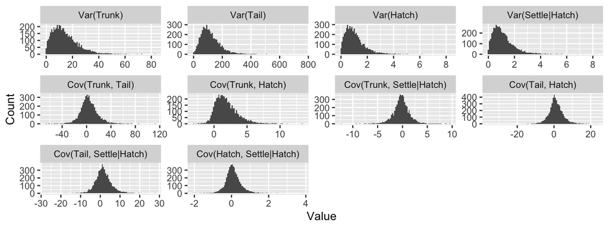

## V<sub>M</sub>

Latent scale

| metric | lower.hdi | median | mode | upper.hdi | pr.lt.hdi | pr.gt.hdi | 5pc.exceeds | pct.gt.0 |
| --- | --- | --- | --- | --- | --- | --- | --- | --- |
| Var(Trunk) | 5.599 | 21.9 | 19.21 | 44.6 | 0.0096 | 0.0402 | 42.99 | 0.9998 |
| Var(Tail) | 39.63 | 147.9 | 134 | 297.9 | 0.0072 | 0.0426 | 286.1 | 0.9996 |
| Var(Hatch) | -0.4 | 0.2635 | 0.2241 | 0.9986 | 0.017 | 0.0328 | 0.889 | 0.8384 |
| Var(Settle\|Hatch) | -0.5298 | 0.1039 | 0.1213 | 0.7755 | 0.0248 | 0.025 | 0.6126 | 0.6666 |
| Cov(Trunk, Tail) | -6.123 | 23.14 | 20.07 | 65.4 | 0.0226 | 0.0272 | 59.03 | 0.9452 |
| Cov(Trunk, Hatch) | -1.188 | 1.015 | 0.823 | 3.482 | 0.0134 | 0.0364 | 3.198 | 0.8482 |
| Cov(Trunk, Settle\|Hatch) | -1.512 | 0.5463 | 0.453 | 2.829 | 0.0196 | 0.0302 | 2.485 | 0.7294 |
| Cov(Tail, Hatch) | -1.42 | 3.766 | 3.706 | 10.8 | 0.0242 | 0.0256 | 9.379 | 0.9266 |
| Cov(Tail, Settle\|Hatch) | -7.84 | -2.519 | -2.4 | 2.341 | 0.0322 | 0.0176 | 1.229 | 0.138 |
| Cov(Hatch, Settle\|Hatch) | -0.575 | -0.185 | -0.1714 | 0.1675 | 0.0348 | 0.015 | 0.0787 | 0.1176 |

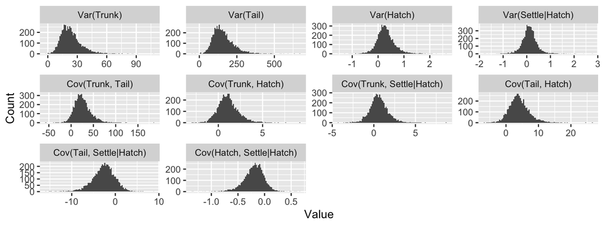

## V<sub>D</sub>

Latent scale

| metric | lower.hdi | median | mode | upper.hdi | pr.lt.hdi | pr.gt.hdi | 5pc.exceeds | pct.gt.0 |
| --- | --- | --- | --- | --- | --- | --- | --- | --- |
| Var(Trunk) | 0.001322 | 9.264 | 5.597 | 26.43 | 0 | 0.0498 | 26.41 | 1 |
| Var(Tail) | 0.06855 | 71.36 | 60.83 | 167.1 | 0 | 0.0498 | 167 | 1 |
| Var(Hatch) | 0.06003 | 1.003 | 0.848 | 2.284 | 0.0046 | 0.0452 | 2.244 | 1 |
| Var(Settle\|Hatch) | 0.5495 | 1.344 | 1.256 | 2.532 | 0.0076 | 0.0422 | 2.463 | 1 |
| Cov(Trunk, Tail) | -12.38 | 5.901 | 3.886 | 32.57 | 0.0142 | 0.0356 | 29.65 | 0.7574 |
| Cov(Trunk, Hatch) | -3.024 | -0.4128 | -0.4251 | 2.115 | 0.0242 | 0.0256 | 1.646 | 0.3328 |
| Cov(Trunk, Settle\|Hatch) | -3.102 | -0.4203 | -0.3568 | 2.098 | 0.0274 | 0.0224 | 1.571 | 0.3488 |
| Cov(Tail, Hatch) | -4.817 | 1.345 | 0.836 | 8.141 | 0.0188 | 0.031 | 7.089 | 0.689 |
| Cov(Tail, Settle\|Hatch) | -7.351 | -1.124 | -1.251 | 4.871 | 0.0264 | 0.0234 | 3.583 | 0.339 |
| Cov(Hatch, Settle\|Hatch) | -0.5034 | 0.2181 | 0.2024 | 0.9433 | 0.024 | 0.0258 | 0.8161 | 0.7472 |

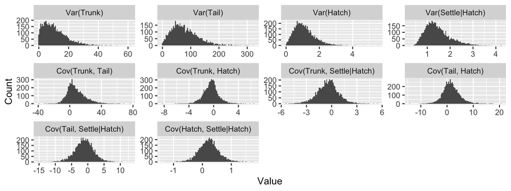

## V<sub>R</sub>

Latent scale

| metric | lower.hdi | median | mode | upper.hdi | pr.lt.hdi | pr.gt.hdi | 5pc.exceeds | pct.gt.0 |
| --- | --- | --- | --- | --- | --- | --- | --- | --- |
| Var(Trunk) | 81.74 | 88.95 | 88.98 | 96.62 | 0.021 | 0.0288 | 95.57 | 1 |
| Var(Tail) | 301.7 | 329.2 | 330.3 | 359.5 | 0.024 | 0.0258 | 355 | 1 |
| Var(Hatch) | 0 | 0 | 0 | 0 | 0 | 0 | 0 | 0 |
| Var(Settle\|Hatch) | 0 | 0 | 0 | 0 | 0 | 0 | 0 | 0 |
| Cov(Trunk, Tail) | 40.35 | 50.94 | 50.42 | 62.2 | 0.025 | 0.0248 | 60.41 | 1 |
| Cov(Trunk, Hatch) | 0 | 0 | 0 | 0 | 0 | 0 | 0 | 0 |
| Cov(Trunk, Settle\|Hatch) | 0 | 0 | 0 | 0 | 0 | 0 | 0 | 0 |
| Cov(Tail, Hatch) | 0 | 0 | 0 | 0 | 0 | 0 | 0 | 0 |
| Cov(Tail, Settle\|Hatch) | 0 | 0 | 0 | 0 | 0 | 0 | 0 | 0 |
| Cov(Hatch, Settle\|Hatch) | 0 | 0 | 0 | 0 | 0 | 0 | 0 | 0 |

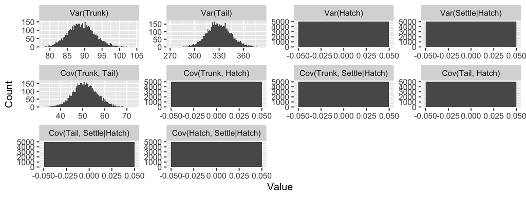

## V<sub>P</sub>

Latent scale

| metric | lower.hdi | median | mode | upper.hdi | pr.lt.hdi | pr.gt.hdi | 5pc.exceeds | pct.gt.0 |
| --- | --- | --- | --- | --- | --- | --- | --- | --- |
| Var(Trunk) | 104.5 | 120.8 | 118.7 | 145.1 | 0.0118 | 0.038 | 142.7 | 1 |
| Var(Tail) | 454.6 | 555.7 | 541.8 | 709.9 | 0.012 | 0.0378 | 694.6 | 1 |
| Var(Hatch) | 0.5287 | 1.04 | 0.9569 | 1.813 | 0.0092 | 0.0406 | 1.751 | 1 |
| Var(Settle\|Hatch) | 0.5311 | 0.9868 | 0.9332 | 1.705 | 0.0084 | 0.0414 | 1.659 | 1 |
| Cov(Trunk, Tail) | 44.68 | 78.53 | 75.73 | 119.7 | 0.0166 | 0.0332 | 114.9 | 0.9998 |
| Cov(Trunk, Hatch) | -0.3139 | 1.797 | 1.583 | 4.447 | 0.018 | 0.0318 | 4.095 | 0.9652 |
| Cov(Trunk, Settle\|Hatch) | -1.716 | 0.3161 | 0.2472 | 2.667 | 0.0224 | 0.0274 | 2.241 | 0.634 |
| Cov(Tail, Hatch) | -0.9502 | 4.672 | 4.776 | 11.02 | 0.0182 | 0.0316 | 10.19 | 0.9618 |
| Cov(Tail, Settle\|Hatch) | -7.589 | -2.102 | -1.961 | 2.656 | 0.0268 | 0.023 | 1.77 | 0.1778 |
| Cov(Hatch, Settle\|Hatch) | -0.5008 | -0.09172 | -0.07838 | 0.2835 | 0.028 | 0.0218 | 0.2116 | 0.3016 |

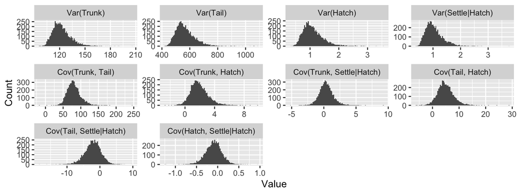

## V<sub>M</sub> / V<sub>A</sub>

Latent scale

| metric | lower.hdi | median | mode | upper.hdi | pr.lt.hdi | pr.gt.hdi | 5pc.exceeds | pct.gt.1 |
| --- | --- | --- | --- | --- | --- | --- | --- | --- |
| Var(Trunk) | 0.0005249 | 1.817 | 1.146 | 13.02 | 0.0002 | 0.0496 | 12.91 | 0.7474 |
| Var(Tail) | 0.009794 | 1.473 | 1.037 | 6.108 | 0.0004 | 0.0494 | 6.083 | 0.682 |
| Var(Hatch) | -0.2286 | 0.3186 | 0.109 | 3.127 | 0.0004 | 0.0494 | 3.114 | 0.2014 |
| Var(Settle\|Hatch) | -0.2489 | 0.123 | -0.02276 | 2.111 | 0 | 0.0498 | 2.101 | 0.115 |
| Cov(Trunk, Tail) | -33.14 | 0.534 | 0.3667 | 38.19 | 0.025 | 0.0248 | 18.6 | 0.4318 |
| Cov(Trunk, Hatch) | -11.1 | 0.4475 | 0.3047 | 12.65 | 0.0242 | 0.0256 | 6.469 | 0.3094 |
| Cov(Trunk, Settle\|Hatch) | -11.47 | -0.3046 | -0.3896 | 11.28 | 0.0266 | 0.0232 | 5.237 | 0.1684 |
| Cov(Tail, Hatch) | -24.49 | 0.2793 | -0.0918 | 25.57 | 0.0248 | 0.025 | 13.03 | 0.3556 |
| Cov(Tail, Settle\|Hatch) | -10.41 | -0.5031 | -0.5383 | 12.61 | 0.0272 | 0.0226 | 5.601 | 0.1688 |
| Cov(Hatch, Settle\|Hatch) | -11.58 | -0.3392 | -0.4173 | 8.592 | 0.0214 | 0.0284 | 4.574 | 0.1638 |

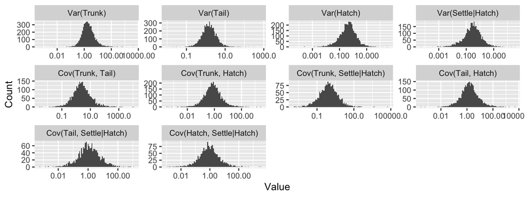

## V<sub>D</sub> / V<sub>A</sub>

Latent scale

| metric | lower.hdi | median | mode | upper.hdi | pr.lt.hdi | pr.gt.hdi | 5pc.exceeds | pct.gt.1 |
| --- | --- | --- | --- | --- | --- | --- | --- | --- |
| Var(Trunk) | 0.00005892 | 0.6925 | 0.3465 | 7.731 | 0 | 0.0498 | 7.709 | 0.3884 |
| Var(Tail) | 0.0004728 | 0.6434 | 0.3913 | 3.933 | 0 | 0.0498 | 3.907 | 0.3314 |
| Var(Hatch) | 0.001468 | 1.055 | 0.6052 | 9.9 | 0 | 0.0498 | 9.823 | 0.5206 |
| Var(Settle\|Hatch) | 0.0697 | 1.377 | 0.8523 | 10.67 | 0 | 0.0498 | 10.65 | 0.6478 |
| Cov(Trunk, Tail) | -14.29 | 0.009454 | -0.01422 | 14.99 | 0.029 | 0.0208 | 6.608 | 0.2332 |
| Cov(Trunk, Hatch) | -8.112 | -0.1954 | -0.2952 | 7.696 | 0.0246 | 0.0252 | 3.245 | 0.116 |
| Cov(Trunk, Settle\|Hatch) | -12.73 | -0.04328 | -0.1067 | 18.16 | 0.0282 | 0.0216 | 7.358 | 0.2256 |
| Cov(Tail, Hatch) | -14.41 | -0.002071 | -0.08184 | 17 | 0.0264 | 0.0234 | 8.052 | 0.2328 |
| Cov(Tail, Settle\|Hatch) | -11.07 | -0.2447 | -0.3145 | 9.296 | 0.0246 | 0.0252 | 4.76 | 0.1632 |
| Cov(Hatch, Settle\|Hatch) | -19.53 | -0.02287 | -0.01291 | 15.47 | 0.0224 | 0.0274 | 8.179 | 0.2606 |

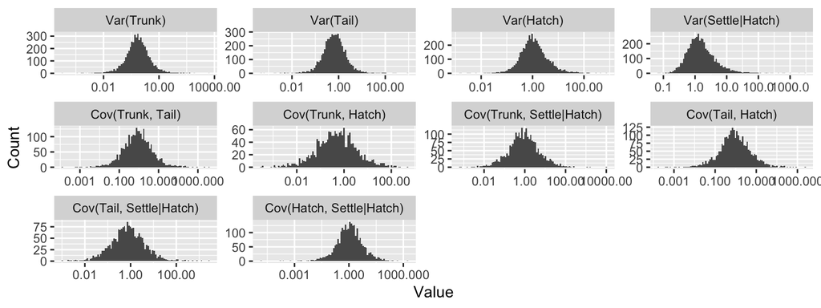

## Variance partitioning

Latent scale  
$(VA / VP) \times 100$

|  | Trunk | Tail |
| --- | --- | --- |
| **lower.hdi** | 0.003377 | 0.98 |
| **median** | 10.26 | 18.77 |
| **mode** | 7.73 | 16.1 |
| **upper.hdi** | 26.84 | 43.51 |
| **pr.lt.hdi** | 0 | 0.0042 |
| **pr.gt.hdi** | 0.0498 | 0.0456 |
| **5pc.exceeds** | 26.81 | 42.98 |

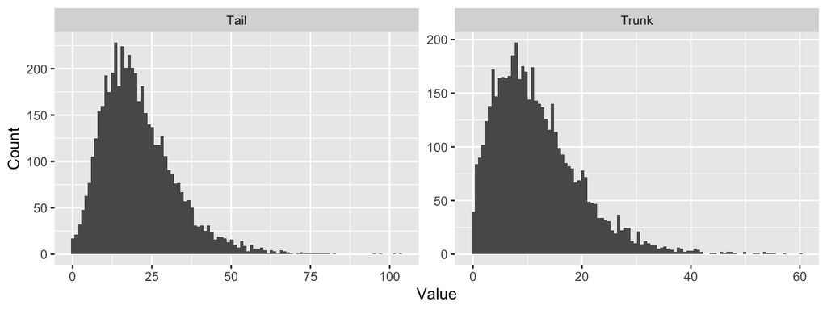

$(VM / VP) \times 100$

|  | Trunk | Tail |
| --- | --- | --- |
| **lower.hdi** | 6.84 | 11.38 |
| **median** | 18.29 | 26.67 |
| **mode** | 17.59 | 25.58 |
| **upper.hdi** | 33.28 | 45.3 |
| **pr.lt.hdi** | 0.023 | 0.025 |
| **pr.gt.hdi** | 0.0268 | 0.0248 |
| **5pc.exceeds** | 30.68 | 42.26 |

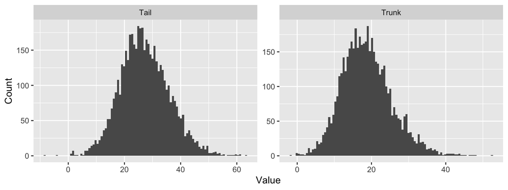

$(VD / VP) \times 100$

|  | Trunk | Tail |
| --- | --- | --- |
| **lower.hdi** | 0.001147 | 0.01092 |
| **median** | 7.531 | 12.64 |
| **mode** | 4.514 | 10.28 |
| **upper.hdi** | 21.62 | 30.02 |
| **pr.lt.hdi** | 0 | 0 |
| **pr.gt.hdi** | 0.0498 | 0.0498 |
| **5pc.exceeds** | 21.61 | 30.02 |

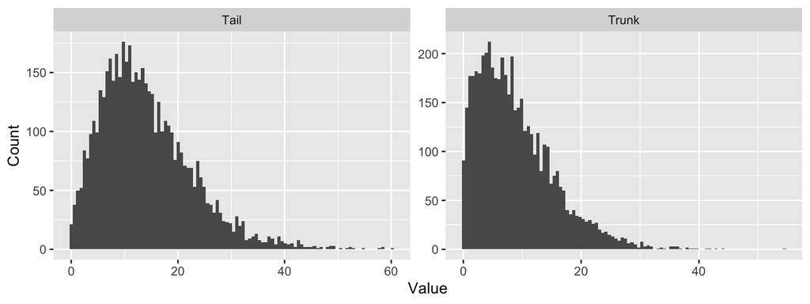

## Summarize QGmvparams posteriors

### Block means on expected data scale

Hatching actually measured in blocks 5, 7, 8, 9, 10, 11, 12, 13, 14, 16  
Settling actually measured in blocks 3, 4, 5, 7, 8, 9, 10, 11, 12, 14  
But **Block** has been re-coded for running model in runjags().

| Block | Stage | lower.hdi | median | mode | upper.hdi | pr.lt.hdi | pr.gt.hdi | 5pc.exceeds |
| --- | --- | --- | --- | --- | --- | --- | --- | --- |
| 3 | Hatch | NA | NA | NA | NA | NA | NA | NA |
| 4 | Hatch | NA | NA | NA | NA | NA | NA | NA |
| 5 | Hatch | 0.5 | 0.78 | 0.84 | 0.96 | 0.043 | 0.0068 | 0.93 |
| 7 | Hatch | 0.54 | 0.79 | 0.85 | 0.96 | 0.043 | 0.0066 | 0.93 |
| 8 | Hatch | 0.52 | 0.78 | 0.83 | 0.95 | 0.039 | 0.01 | 0.93 |
| 9 | Hatch | 0.67 | 0.87 | 0.91 | 0.97 | 0.048 | 0.0018 | 0.96 |
| 10 | Hatch | 0.47 | 0.71 | 0.73 | 0.93 | 0.032 | 0.018 | 0.9 |
| 11 | Hatch | 0.48 | 0.72 | 0.77 | 0.93 | 0.037 | 0.013 | 0.9 |
| 12 | Hatch | 0.7 | 0.89 | 0.92 | 0.98 | 0.05 | 0 | 0.96 |
| 13 | Hatch | 0.56 | 0.8 | 0.84 | 0.96 | 0.046 | 0.0038 | 0.93 |
| 14 | Hatch | 0.63 | 0.85 | 0.89 | 0.97 | 0.048 | 0.0018 | 0.95 |
| 16 | Hatch | 0.77 | 0.92 | 0.95 | 0.98 | 0.049 | 0.0006 | 0.97 |
| 3 | Settle\|Hatch | 0.5 | 0.81 | 0.88 | 0.97 | 0.048 | 0.002 | 0.95 |
| 4 | Settle\|Hatch | 0.57 | 0.86 | 0.91 | 0.97 | 0.05 | 0.0002 | 0.96 |
| 5 | Settle\|Hatch | 0.41 | 0.74 | 0.81 | 0.96 | 0.048 | 0.0016 | 0.93 |
| 7 | Settle\|Hatch | 0.62 | 0.87 | 0.92 | 0.97 | 0.049 | 0.0006 | 0.96 |
| 8 | Settle\|Hatch | 0.45 | 0.76 | 0.83 | 0.96 | 0.043 | 0.0066 | 0.93 |
| 9 | Settle\|Hatch | 0.34 | 0.64 | 0.72 | 0.92 | 0.037 | 0.013 | 0.88 |
| 10 | Settle\|Hatch | 0.32 | 0.66 | 0.71 | 0.91 | 0.021 | 0.029 | 0.89 |
| 11 | Settle\|Hatch | 0.33 | 0.65 | 0.73 | 0.91 | 0.026 | 0.023 | 0.88 |
| 12 | Settle\|Hatch | 0.35 | 0.65 | 0.71 | 0.93 | 0.04 | 0.01 | 0.89 |
| 13 | Settle\|Hatch | NA | NA | NA | NA | NA | NA | NA |
| 14 | Settle\|Hatch | 0.54 | 0.82 | 0.88 | 0.97 | 0.049 | 0.0004 | 0.95 |
| 16 | Settle\|Hatch | NA | NA | NA | NA | NA | NA | NA |

Summary across blocks

| Stage | min | max | mean_median | mean_mode |
| --- | --- | --- | --- | --- |
| Hatch | 0.71 | 0.92 | 0.81 | 0.85 |
| Settle\|Hatch | 0.64 | 0.87 | 0.75 | 0.81 |

### Block means on latent scale

| Block | Hatch | Settle\|Hatch |
| --- | --- | --- |
| 3 | NA | 1.7 |
| 4 | NA | 2.1 |
| 5 | 1.5 | 1.3 |
| 7 | 1.6 | 2.2 |
| 8 | 1.5 | 1.4 |
| 9 | 2.3 | 0.77 |
| 10 | 1.2 | 0.82 |
| 11 | 1.2 | 0.78 |
| 12 | 2.4 | 0.79 |
| 13 | 1.7 | NA |
| 14 | 2.1 | 1.8 |
| 16 | 2.8 | NA |

### VA for settling and hatching on data scale across blocks

| Block | Stage | lower.hdi | median | mode | upper.hdi | pr.lt.hdi | pr.gt.hdi | 5pc.exceeds | pct.gt.0 |
| --- | --- | --- | --- | --- | --- | --- | --- | --- | --- |
| 1 | Var(Hatch) | 0.0028 | 0.9 | 0.68 | 2.6 | 0 | 0.05 | 2.6 | 1 |
| 2 | Var(Hatch) | 0.0028 | 0.9 | 0.68 | 2.6 | 0 | 0.05 | 2.6 | 1 |
| 3 | Var(Hatch) | 0.0028 | 0.9 | 0.68 | 2.6 | 0 | 0.05 | 2.6 | 1 |
| 4 | Var(Hatch) | 0.0028 | 0.9 | 0.68 | 2.6 | 0 | 0.05 | 2.6 | 1 |
| 5 | Var(Hatch) | 0.000028 | 0.017 | 0.0084 | 0.068 | 0 | 0.05 | 0.068 | 1 |
| 7 | Var(Hatch) | 0.000016 | 0.015 | 0.0077 | 0.064 | 0 | 0.05 | 0.064 | 1 |
| 8 | Var(Hatch) | 0.000022 | 0.017 | 0.0087 | 0.067 | 0 | 0.05 | 0.067 | 1 |
| 9 | Var(Hatch) | 0.0000093 | 0.0072 | 0.0036 | 0.046 | 0 | 0.05 | 0.046 | 1 |
| 10 | Var(Hatch) | 0.00007 | 0.022 | 0.012 | 0.076 | 0.0002 | 0.05 | 0.076 | 1 |
| 11 | Var(Hatch) | 0.000056 | 0.021 | 0.011 | 0.074 | 0.0002 | 0.05 | 0.074 | 1 |
| 12 | Var(Hatch) | 0.0000053 | 0.0065 | 0.0033 | 0.04 | 0 | 0.05 | 0.04 | 1 |
| 13 | Var(Hatch) | 0.000036 | 0.015 | 0.0076 | 0.062 | 0 | 0.05 | 0.062 | 1 |
| 14 | Var(Hatch) | 0.0000038 | 0.0096 | 0.0048 | 0.05 | 0 | 0.05 | 0.05 | 1 |
| 15 | Var(Hatch) | 0.0028 | 0.9 | 0.68 | 2.6 | 0 | 0.05 | 2.6 | 1 |
| 16 | Var(Hatch) | 0.0000049 | 0.0036 | 0.0018 | 0.028 | 0 | 0.05 | 0.028 | 1 |
| 1 | Var(Settle\|Hatch) | 0.001 | 0.95 | 0.66 | 2.8 | 0.0002 | 0.05 | 2.8 | 1 |
| 2 | Var(Settle\|Hatch) | 0.001 | 0.95 | 0.66 | 2.8 | 0.0002 | 0.05 | 2.8 | 1 |
| 3 | Var(Settle\|Hatch) | 0.0000031 | 0.014 | 0.0073 | 0.067 | 0 | 0.05 | 0.067 | 1 |
| 4 | Var(Settle\|Hatch) | 0.000007 | 0.01 | 0.0051 | 0.06 | 0 | 0.05 | 0.059 | 1 |
| 5 | Var(Settle\|Hatch) | 0.000027 | 0.021 | 0.011 | 0.08 | 0.0002 | 0.05 | 0.08 | 1 |
| 7 | Var(Settle\|Hatch) | 0.0000052 | 0.0091 | 0.0045 | 0.054 | 0 | 0.05 | 0.054 | 1 |
| 8 | Var(Settle\|Hatch) | 0.000013 | 0.019 | 0.0095 | 0.078 | 0 | 0.05 | 0.078 | 1 |
| 9 | Var(Settle\|Hatch) | 0.000029 | 0.027 | 0.015 | 0.087 | 0 | 0.05 | 0.087 | 1 |
| 10 | Var(Settle\|Hatch) | 0.000026 | 0.027 | 0.014 | 0.086 | 0 | 0.05 | 0.086 | 1 |
| 11 | Var(Settle\|Hatch) | 0.000031 | 0.028 | 0.015 | 0.088 | 0 | 0.05 | 0.087 | 1 |
| 12 | Var(Settle\|Hatch) | 0.000031 | 0.027 | 0.015 | 0.088 | 0 | 0.05 | 0.088 | 1 |
| 13 | Var(Settle\|Hatch) | 0.001 | 0.95 | 0.66 | 2.8 | 0.0002 | 0.05 | 2.8 | 1 |
| 14 | Var(Settle\|Hatch) | 0.000012 | 0.013 | 0.0067 | 0.068 | 0 | 0.05 | 0.068 | 1 |
| 15 | Var(Settle\|Hatch) | 0.001 | 0.95 | 0.66 | 2.8 | 0.0002 | 0.05 | 2.8 | 1 |
| 16 | Var(Settle\|Hatch) | 0.001 | 0.95 | 0.66 | 2.8 | 0.0002 | 0.05 | 2.8 | 1 |

[output cut: 75 more lines]

### VP for settling and hatching on data scale across blocks

| Block | Stage | lower.hdi | median | mode | upper.hdi | pr.lt.hdi | pr.gt.hdi | 5pc.exceeds | pct.gt.0 |
| --- | --- | --- | --- | --- | --- | --- | --- | --- | --- |
| 1 | Var(Hatch) | 0.53 | 1 | 0.96 | 1.8 | 0.0092 | 0.041 | 1.8 | 1 |
| 2 | Var(Hatch) | 0.53 | 1 | 0.96 | 1.8 | 0.0092 | 0.041 | 1.8 | 1 |
| 3 | Var(Hatch) | 0.53 | 1 | 0.96 | 1.8 | 0.0092 | 0.041 | 1.8 | 1 |
| 4 | Var(Hatch) | 0.53 | 1 | 0.96 | 1.8 | 0.0092 | 0.041 | 1.8 | 1 |
| 5 | Var(Hatch) | 0.063 | 0.17 | 0.21 | 0.25 | 0.05 | 0 | 0.25 | 1 |
| 7 | Var(Hatch) | 0.063 | 0.16 | 0.21 | 0.25 | 0.05 | 0.0002 | 0.25 | 1 |
| 8 | Var(Hatch) | 0.069 | 0.17 | 0.21 | 0.25 | 0.05 | 0 | 0.25 | 1 |
| 9 | Var(Hatch) | 0.028 | 0.11 | 0.083 | 0.22 | 0.005 | 0.045 | 0.22 | 1 |
| 10 | Var(Hatch) | 0.093 | 0.2 | 0.23 | 0.25 | 0.05 | 0 | 0.25 | 1 |
| 11 | Var(Hatch) | 0.088 | 0.2 | 0.23 | 0.25 | 0.05 | 0.0002 | 0.25 | 1 |
| 12 | Var(Hatch) | 0.025 | 0.1 | 0.073 | 0.21 | 0.002 | 0.048 | 0.21 | 1 |
| 13 | Var(Hatch) | 0.062 | 0.16 | 0.21 | 0.25 | 0.049 | 0.0006 | 0.25 | 1 |
| 14 | Var(Hatch) | 0.033 | 0.13 | 0.099 | 0.24 | 0.011 | 0.038 | 0.23 | 1 |
| 15 | Var(Hatch) | 0.53 | 1 | 0.96 | 1.8 | 0.0092 | 0.041 | 1.8 | 1 |
| 16 | Var(Hatch) | 0.024 | 0.072 | 0.051 | 0.18 | 0.0026 | 0.047 | 0.18 | 1 |
| 1 | Var(Settle\|Hatch) | 0.53 | 0.99 | 0.93 | 1.7 | 0.0084 | 0.041 | 1.7 | 1 |
| 2 | Var(Settle\|Hatch) | 0.53 | 0.99 | 0.93 | 1.7 | 0.0084 | 0.041 | 1.7 | 1 |
| 3 | Var(Settle\|Hatch) | 0.046 | 0.15 | 0.2 | 0.25 | 0.048 | 0.0014 | 0.25 | 1 |
| 4 | Var(Settle\|Hatch) | 0.038 | 0.12 | 0.078 | 0.25 | 0.05 | 0 | 0.24 | 1 |
| 5 | Var(Settle\|Hatch) | 0.066 | 0.19 | 0.22 | 0.25 | 0.05 | 0.0002 | 0.25 | 1 |
| 7 | Var(Settle\|Hatch) | 0.027 | 0.12 | 0.077 | 0.24 | 0.0028 | 0.047 | 0.23 | 1 |
| 8 | Var(Settle\|Hatch) | 0.066 | 0.18 | 0.22 | 0.25 | 0.05 | 0 | 0.25 | 1 |
| 9 | Var(Settle\|Hatch) | 0.1 | 0.22 | 0.24 | 0.25 | 0.05 | 0 | 0.25 | 1 |
| 10 | Var(Settle\|Hatch) | 0.099 | 0.22 | 0.23 | 0.25 | 0.05 | 0 | 0.25 | 1 |
| 11 | Var(Settle\|Hatch) | 0.1 | 0.22 | 0.24 | 0.25 | 0.05 | 0 | 0.25 | 1 |
| 12 | Var(Settle\|Hatch) | 0.1 | 0.22 | 0.24 | 0.25 | 0.05 | 0 | 0.25 | 1 |
| 13 | Var(Settle\|Hatch) | 0.53 | 0.99 | 0.93 | 1.7 | 0.0084 | 0.041 | 1.7 | 1 |
| 14 | Var(Settle\|Hatch) | 0.048 | 0.15 | 0.2 | 0.25 | 0.05 | 0.0002 | 0.25 | 1 |
| 15 | Var(Settle\|Hatch) | 0.53 | 0.99 | 0.93 | 1.7 | 0.0084 | 0.041 | 1.7 | 1 |
| 16 | Var(Settle\|Hatch) | 0.53 | 0.99 | 0.93 | 1.7 | 0.0084 | 0.041 | 1.7 | 1 |

[output cut: 75 more lines]

## Genetic selection gradients

$\boldsymbol{\beta}_{g} = \mathbf{G}^{-1}\mathbf{s}_{g}$

Table continues below

| W | Variable | lower.hdi | median |
| --- | --- | --- | --- |
| Hatch | Trunk | -0.0614227368795026 | 0.0193281434583072 |
| Hatch | Tail | -0.0368303844244766 | 0.00046355931443706 |
| Settle\|Hatch | Trunk | -0.254573332111787 | -0.00334504446182177 |
| Settle\|Hatch | Tail | -0.0380041593808602 | 0.00233092567271732 |
| Total | Trunk | -0.23336434296571 | 0.0157892703542818 |
| Total | Tail | -0.0580783559775135 | 0.00372105412584925 |

Table continues below

| mode | upper.hdi | pr.lt.hdi | pr.gt.hdi |
| --- | --- | --- | --- |
| 0.0116327762760476 | 0.276745670271882 | 0.00686 | 0.04312 |
| 0.000541115810445994 | 0.0422302076894497 | 0.02212 | 0.02786 |
| -0.00334004499474265 | 0.188695271575917 | 0.0252 | 0.02478 |
| 0.00157370083924479 | 0.0600325297802316 | 0.02032 | 0.02966 |
| 0.0124859146219217 | 0.434660782022791 | 0.018025 | 0.03195 |
| 0.00328802580879171 | 0.0836143200565528 | 0.02015 | 0.029825 |

| 5pc.exceeds |
| --- |
| 0.24437268079356 |
| 0.0272761595595216 |
| 0.100782814668104 |
| 0.0417859788772761 |
| 0.294431082076629 |
| 0.0579955782238898 |

## Evolvability (for single traits)

|  | Trunk | Tail |
| --- | --- | --- |
| **lower.hdi** | 0.0000003545 | 0.0000104 |
| **median** | 0.0002984 | 0.0005161 |
| **mode** | 0.0002126 | 0.0004477 |
| **upper.hdi** | 0.0007998 | 0.00122 |
| **pr.lt.hdi** | 0.0002 | 0.0016 |
| **pr.gt.hdi** | 0.0496 | 0.0482 |
| **5pc.exceeds** | 0.0007995 | 0.001217 |

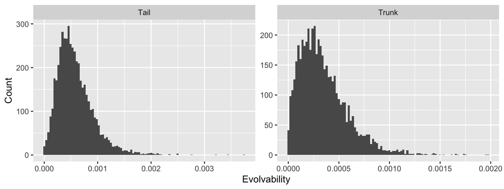

Evolvability as a percentage

|  | Trunk | Tail |
| --- | --- | --- |
| **lower.hdi** | 0.00003545 | 0.00104 |
| **median** | 0.02984 | 0.05161 |
| **mode** | 0.02126 | 0.04477 |
| **upper.hdi** | 0.07998 | 0.122 |
| **pr.lt.hdi** | 0.0002 | 0.0016 |
| **pr.gt.hdi** | 0.0496 | 0.0482 |
| **5pc.exceeds** | 0.07995 | 0.1217 |

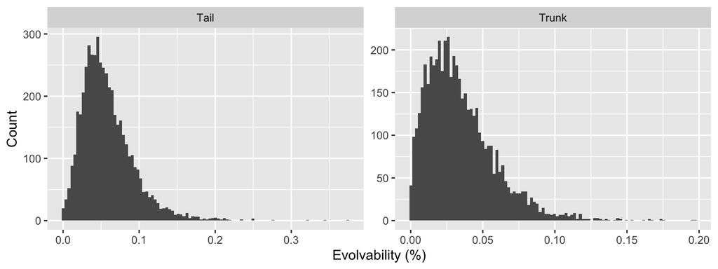

## Tail / Trunk Evolvability

| lower.hdi | median | mode | upper.hdi | pr.lt.hdi | pr.gt.hdi | 5pc.exceeds |
| --- | --- | --- | --- | --- | --- | --- |
| 0.2176 | 1.77 | 1.69 | 18.03 | 1.018 | 1.032 | 12.22 |

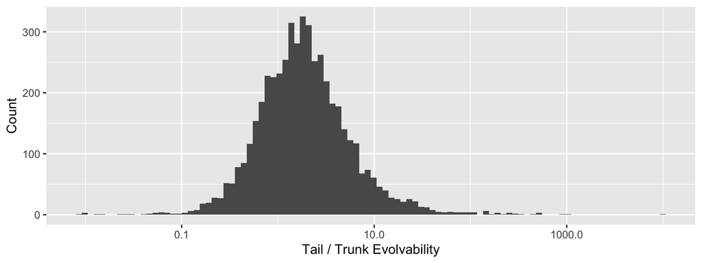

## Evolvability (from G matrix) Approach 1

This is for a random set of selection gradients.  
Multiply eB by 100 to get in units of percent.

| name | lower.hdi | median | mode | upper.hdi | pr.lt.hdi | pr.gt.hdi | 5pc.exceeds |
| --- | --- | --- | --- | --- | --- | --- | --- |
| eB | 0.000034 | 0.000245 | 0.000217 | 0.000548 | 0.0052 | 0.0446 | 0.000536 |
| rB | 0.000048 | 0.000286 | 0.000233 | 0.00068 | 0.0086 | 0.0412 | 0.000654 |
| cB | 0.000014 | 0.000133 | 0.000119 | 0.000278 | 0.0056 | 0.0442 | 0.000272 |
| iB | 0.01094 | 0.4384 | 0.4418 | 0.787 | 0.0036 | 0.0462 | 0.7816 |
| aB | 0.213 | 0.5616 | 0.5582 | 0.9891 | 0.0462 | 0.0036 | 0.9061 |

## Evolvability (from G matrix) Approach 2

This is for a specific set of selection gradients:  
Beta_index = 1 is $\beta = \begin{bmatrix} 0 \\ 1 \end{bmatrix}$ = strong selection for longer tails only  
Beta_index = 2 is $\beta = \begin{bmatrix} -(1/\sqrt2) \\ -(1/\sqrt2) \end{bmatrix}$ = strong selection for shorter trunks and shorter tails  
Beta_index = 3 is $\beta = \begin{bmatrix} (1/\sqrt2) \\ -(1/\sqrt2) \end{bmatrix}$ = strong selection for longer trunks and shorter tails  
Multiply ‘evolvability’ by 100 to get in units of percent.

| Beta_index | metric | lower.hdi | median | mode | upper.hdi | pr.lt.hdi | pr.gt.hdi | 5pc.exceeds |
| --- | --- | --- | --- | --- | --- | --- | --- | --- |
| 1 | evolvability | 0.00001 | 0.000516 | 0.000448 | 0.00122 | 0.0016 | 0.0482 | 0.001217 |
| 2 | evolvability | 0.000049 | 0.00045 | 0.000389 | 0.001084 | 0.004 | 0.0458 | 0.00106 |
| 3 | evolvability | 0.000064 | 0.000381 | 0.000353 | 0.000874 | 0.0086 | 0.0412 | 0.000846 |
| 1 | respondability | 0.000057 | 0.000536 | 0.000454 | 0.001283 | 0.0068 | 0.043 | 0.001248 |
| 2 | respondability | 0.000067 | 0.000496 | 0.000416 | 0.001157 | 0.005 | 0.0448 | 0.001123 |
| 3 | respondability | 0.000072 | 0.000426 | 0.000366 | 0.00098 | 0.0058 | 0.044 | 0.00095 |
| 1 | conditional | 0.000002 | 0.000446 | 0.000369 | 0.001055 | 0.0002 | 0.0496 | 0.001054 |
| 2 | conditional | 0 | 0.000339 | 0.000276 | 0.00089 | 0 | 0.0498 | 0.00089 |
| 3 | conditional | 0 | 0.000286 | 0.000231 | 0.000692 | 0 | 0.0498 | 0.000691 |
| 1 | autonomy (cB/eB) | 0.5244 | 0.9302 | 0.9651 | 1 | 0.0498 | 0 | 0.9994 |
| 2 | autonomy (cB/eB) | 0.2075 | 0.8539 | 0.927 | 1 | 0.0498 | 0 | 0.9984 |
| 3 | autonomy (cB/eB) | 0.2075 | 0.8539 | 0.927 | 1 | 0.0498 | 0 | 0.9984 |
| 1 | integration | 0 | 0.06979 | 0.03488 | 0.4756 | 0 | 0.0498 | 0.4756 |
| 2 | integration | 0 | 0.1461 | 0.07299 | 0.7925 | 0 | 0.0498 | 0.7924 |
| 3 | integration | 0 | 0.1461 | 0.07299 | 0.7925 | 0 | 0.0498 | 0.7924 |

## Response to selection (%) from covariance. Approach 3

| param | lower.hdi | median | mode | upper.hdi | pr.lt.hdi | pr.gt.hdi | 5pc.exceeds |
| --- | --- | --- | --- | --- | --- | --- | --- |
| Tail : Settle\|Hatch | -0.3954 | 0.04505 | 0.03875 | 0.6239 | 0.01984 | 0.03014 | 0.4986 |
| Trunk : Settle\|Hatch | -0.5087 | -0.01641 | -0.01144 | 0.4192 | 0.02538 | 0.0246 | 0.295 |
| Tail : Hatch | -0.3125 | 0.02139 | 0.01384 | 0.4099 | 0.02144 | 0.02854 | 0.3208 |
| Trunk : Hatch | -0.08916 | 0.1055 | 0.06452 | 0.5899 | 0.0123 | 0.03768 | 0.5344 |
| NA | -0.4682 | 0.09732 | 0.07489 | 0.8355 | 0.02259 | 0.0274 | 0.6785 |